# Client Report - Project 4: Can you predict that?

- Show All Code
- Hide All Code

Course DS 250

Author

Julien Connault

## Elevator pitch

**Can you predict that?** *The goal of this project was to build a classification model that predicts whether a house was built before or after 1980. The model has been trained on a dataset of almost 10,000 houses in Denver, Colorado. Using the RandomForestClassifier from scikit-learn, the model is 90% accurate, which indicates that a large proportion of the predictions are correct. The model is also 92% precise, meaning that when the model predicts a positive outcome, it is likely to be correct. Finally, the model has a 92% recall rate which means that the model is good at capturing all positive instances.*

**Read project data**

```python
# libraries
import pandas as pd
import altair as alt
import numpy as np
import seaborn as sns
import matplotlib.pyplot as plt

# scikit learn froms
from sklearn.model_selection import train_test_split

# from sklearn import tree
# from sklearn.naive_bayes import GaussianNB

# from sklearn.ensemble import GradientBoostingClassifier
# from sklearn.ensemble import AdaBoostClassifier
# from sklearn.ensemble import BaggingClassifier
# from sklearn.ensemble import VotingClassifier
from sklearn.ensemble import RandomForestClassifier
from sklearn import metrics
from sklearn.metrics import accuracy_score, precision_score, recall_score

# load data
dwellings_denver = pd.read_csv("dwellings_denver.csv")
dwellings_ml = pd.read_csv("dwellings_ml.csv")
dwellings_neighborhoods_ml = pd.read_csv("dwellings_neighborhoods_ml.csv")

alt.data_transformers.enable("json")


# X_pred = dwellings_ml.drop(dwellings_ml.filter(regex = 'before1980|yrbuilt|parcel').columns, axis = 1)
# y_pred = dwellings_ml.filter(regex = "before1980")
# X_train, X_test, y_train, y_test = train_test_split(
#     X_pred, y_pred, test_size = .34, random_state = 76)

# y_test.mean()
# X_train['sprice'].head(10).mean()

# h_subset = dwellings_ml.filter(
#     [
#         "livearea",
#         "stories",
#         "numbaths",
#         "basement",
#         "nocars",
#         "numbdrm",
#         "sprice",
#         "status_I",
#         "before1980",
#     ]
# ).sample(500)
# sns.pairplot(h_subset, hue="before1980")

# corr = h_subset.drop(columns="before1980").corr()

# sns.heatmap(corr)
```

```
DataTransformerRegistry.enable('json')
```

## QUESTION|TASK 1

**Create 2-3 charts that evaluate potential relationships between the home variables and before1980. Explain what you learn from the charts that could help a machine learning algorithm.**

**three matplotlib charts to show the relationship between the home variables and before1980**

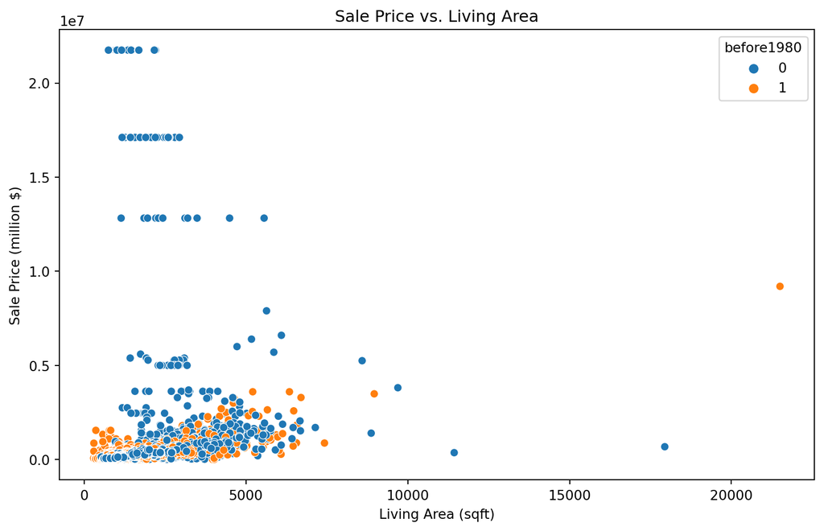

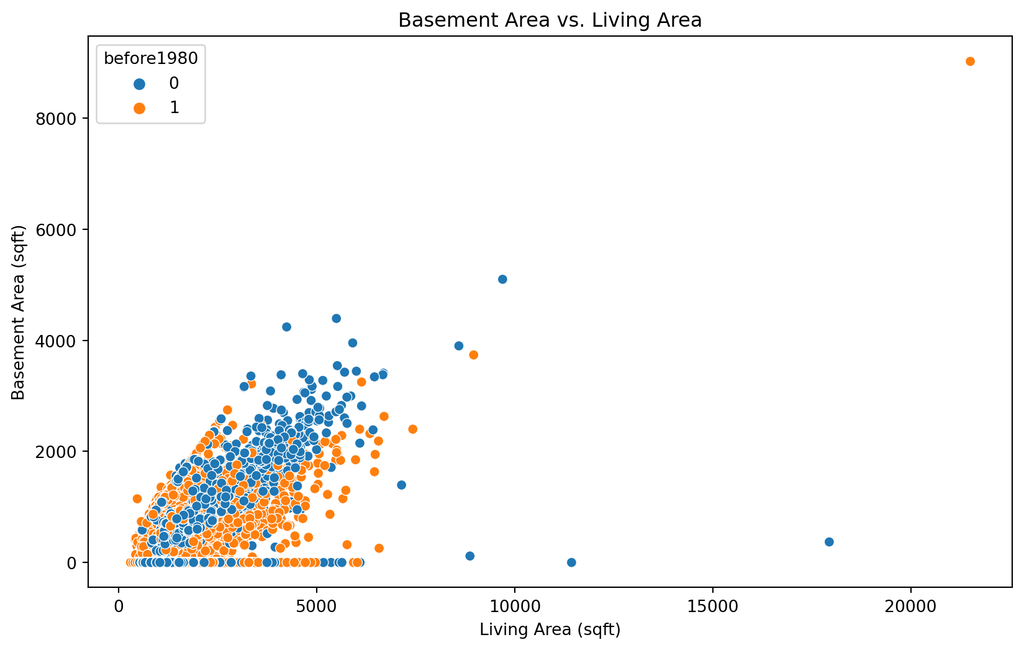

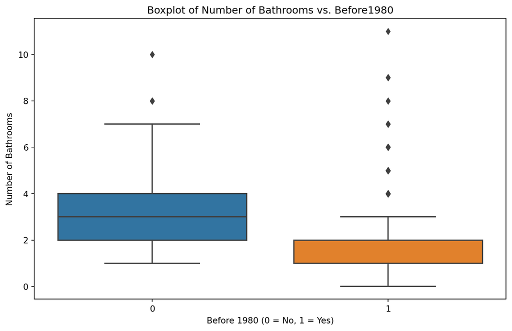

```python
# 1. Sale Price vs. Living Area - Scatterplot
plt.figure(figsize=(10, 6))
sns.scatterplot(data=dwellings_ml, x="livearea", y="sprice", hue="before1980")
plt.xlabel("Living Area (sqft)")
plt.ylabel("Sale Price (million $)")
plt.title("Sale Price vs. Living Area")
plt.show()

# 2. Basement Area vs. Living Area - Scatterplot
plt.figure(figsize=(10, 6))
sns.scatterplot(data=dwellings_ml, x="livearea", y="basement", hue="before1980")
plt.xlabel("Living Area (sqft)")
plt.ylabel("Basement Area (sqft)")
plt.title("Basement Area vs. Living Area")
plt.show()

# 3. Number of Bathrooms vs. Before1980 - Boxplot
plt.figure(figsize=(10, 6))
sns.boxplot(data=dwellings_ml, x="before1980", y="numbaths")
plt.xlabel("Before 1980 (0 = No, 1 = Yes)")
plt.ylabel("Number of Bathrooms")
plt.title("Boxplot of Number of Bathrooms vs. Before1980")
plt.show()
```

## QUESTION|TASK 2

**Build a classification model labeling houses as being built “before 1980” or “during or after 1980”. Your goal is to reach or exceed 90% accuracy. Explain your final model choice (algorithm, tuning parameters, etc) and describe what other models you tried.**

*The Random Forest Classifier was chosen as it had the highest accuracy score of 0.9. The model was trained on 70% of the data and tested on the remaining 30%. The random state was set to 24 to ensure reproducibility. The features used were: basement, nocars, numbdrm, sprice, status_I, livearea, stories, numbaths.* *Those features were chosen as they had the highest importance in the model.* *The model was also tested with other featuresbut the accuracy score was lower than with the features mentioned above.* *The following models were tested:*

- Decision Tree Classifier
- Naive Bayes Classifier
- Gradient Boosting Classifier
- Ada Boost Classifier
- Bagging Classifier
- Voting Classifier

**Classification model labeling houses as being built “before 1980” or “during or after 1980”**

```python
# Selecting the features and the target
X = dwellings_ml[
    [
        "basement",
        "nocars",
        "numbdrm",
        "sprice",
        "status_I",
        "livearea",
        "stories",
        "numbaths",
    ]
]
y = dwellings_ml["before1980"]

# Splitting the data into training and testing sets
X_train, X_test, y_train, y_test = train_test_split(
    X, y, test_size=0.3, random_state=24, stratify=y
)

# Creating the random forest object
rf = RandomForestClassifier(random_state=24)
rf.fit(X_train, y_train)

# Predicting based on the model we've trained
y_pred = rf.predict(X_test)

# Evaluating the model
accuracy_score(y_test, y_pred)
```

```
0.9029677043933663
```

## QUESTION|TASK 3

**Justify your classification model by discussing the most important features selected by your model. This discussion should include a chart and a description of the features.**

*The most important features selected for the model are:*

- livearea: Living area in square feet
- sprice: Sale price in dollars
- basement: Basement area in square feet
- numbaths: Number of bathrooms
- stories: Number of stories

**Chart and description of the most important features selected by the model**

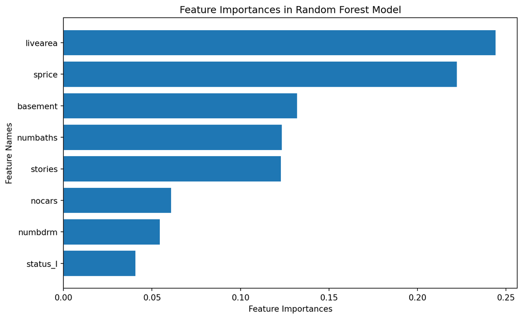

```python
# Plotting the feature importances
feat_imports = pd.DataFrame(
    {"feature names": X_train.columns, "importances": rf.feature_importances_}
).sort_values("importances", ascending=False)

plt.figure(figsize=(10, 6))
plt.barh(feat_imports["feature names"], feat_imports["importances"])
plt.xlabel("Feature Importances")
plt.ylabel("Feature Names")
plt.title("Feature Importances in Random Forest Model")
plt.gca().invert_yaxis()
plt.show()
```

## QUESTION|TASK 4

**Describe the quality of your classification model using 2-3 different evaluation metrics. You also need to explain how to interpret each of the evaluation metrics you use.**

*The quality of the classification model is described using Accuracy, Precision and Recall.* *The model is 90% accurate, which indicates that a large proportion of the predictions are correct.* *We get a 92% precision score, indicating that when the model predicts a positive outcome, it is likely to be correct.* *Finally, we get a 92% recall rate which means that the model is good at capturing all positive instances.*

**Description of the quality of the classification model using Accuracy, Precision and Recall**

```python
# Calculate the metrics
accuracy = accuracy_score(y_test, y_pred)
precision = precision_score(y_test, y_pred)
recall = recall_score(y_test, y_pred)

# Print the metrics
print(f"Accuracy: {accuracy:.2f}")
print(f"Precision: {precision:.2f}")
print(f"Recall: {recall:.2f}")
```

```
Accuracy: 0.90
Precision: 0.92
Recall: 0.92
```

## APPENDIX A (All Python Code)

```
# libraries
import pandas as pd
import altair as alt
import numpy as np
import seaborn as sns
import matplotlib.pyplot as plt

# scikit learn froms
from sklearn.model_selection import train_test_split

# from sklearn import tree
# from sklearn.naive_bayes import GaussianNB

# from sklearn.ensemble import GradientBoostingClassifier
# from sklearn.ensemble import AdaBoostClassifier
# from sklearn.ensemble import BaggingClassifier
# from sklearn.ensemble import VotingClassifier
from sklearn.ensemble import RandomForestClassifier
from sklearn import metrics
from sklearn.metrics import accuracy_score, precision_score, recall_score

# load data
dwellings_denver = pd.read_csv("dwellings_denver.csv")
dwellings_ml = pd.read_csv("dwellings_ml.csv")
dwellings_neighborhoods_ml = pd.read_csv("dwellings_neighborhoods_ml.csv")

alt.data_transformers.enable("json")

# X_pred = dwellings_ml.drop(dwellings_ml.filter(regex = 'before1980|yrbuilt|parcel').columns, axis = 1)
# y_pred = dwellings_ml.filter(regex = "before1980")
# X_train, X_test, y_train, y_test = train_test_split(
#     X_pred, y_pred, test_size = .34, random_state = 76)

# y_test.mean()
# X_train['sprice'].head(10).mean()

# h_subset = dwellings_ml.filter(
#     [
#         "livearea",
#         "stories",
```

[output cut: 77 more lines]

```
plt.ylabel("Feature Names")
plt.title("Feature Importances in Random Forest Model")
plt.gca().invert_yaxis()
plt.show()


# Calculate the metrics
accuracy = accuracy_score(y_test, y_pred)
precision = precision_score(y_test, y_pred)
recall = recall_score(y_test, y_pred)

# Print the metrics
print(f"Accuracy: {accuracy:.2f}")
print(f"Precision: {precision:.2f}")
print(f"Recall: {recall:.2f}")
```